# R Notebook - exploratory analysis of survey papers for JMIR paper

2019-03-01

## Metadata

Required libraries and runtime environment description.

```r
library(emidata)
library(tidyverse)
library(tidytext)
library(kableExtra)
library(stringr)
library(skimr)
library(ggalt)
library(scales)
library(easyalluvial)
library(RColorBrewer)
library(gridExtra)
library(treemap)
```

This document is an EDA notebook to explore descriptive and informative figures of the datasets incldued in the *emidata* package.

## Data

We analyse three datasets:

- *ipapers2018_psydata* (extracted data items related to psychology) has `114` records and `21` columns.
- *ipapers2018_csdata* (extracted data items related to tech/cs) has `129` records and `21` columns.
- *ipapers2018* (list of analysed papers) has `136` records and `9` columns.

The final number of papers to analyse is `111`.

## Exploratory analysis of mental disorders (MDs)

Next exploratory tables and figures attempt to figure out what’s going on. The initial assumption of the paper is that the field of mental disorder (*md*) drives the analysis. So we start exploring the related columns (variables), which are:

```
## [1] "md"      "md_mul"  "md_sub"  "md_id"   "md_desc"
```

### How many distinct MDs are there?

There are `14` distinct MDs (out of 25). About 76.6% (N=85) are categorised according to Section II of [DSM-5 manual](https://dsm.psychiatryonline.org/doi/book/10.1176/appi.books.9780890425596). About 23.4% (N=26) are 23-Dual, 24-Multiple or 25-Suicidal behavior disorder/nonsuicidal self-injury.

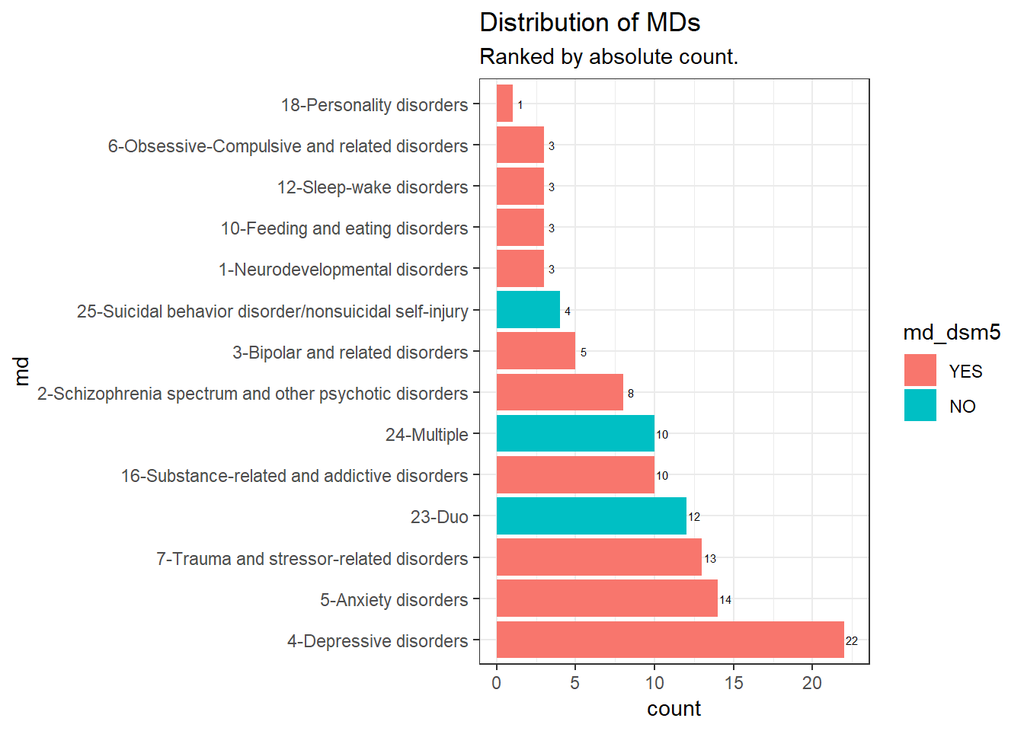

Remarks:

- There appears to be three main groups of MDs: 1/ well-addressed, 2/ marginal, and 3/ ignored. In the group 1, we have for instance the last 4 rows of the above plot, which cover a good proportion of the papers. The second group refers to those MDs that have a reduce number of apps, say less than 4. They are for example the first rows of the above plot. The third group is the MDs that are not shown in the plot.

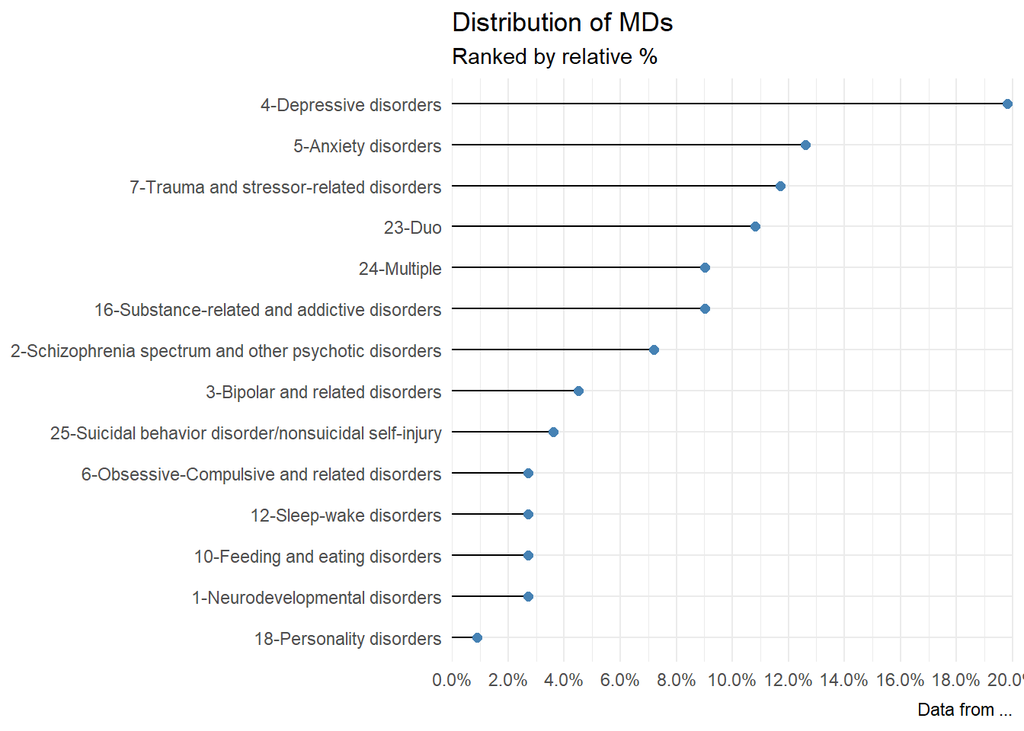

### Top3 MDs?

| md | number_cases | proportion |
| --- | --- | --- |
| 4-Depressive disorders | 22 | 0.20 |
| 5-Anxiety disorders | 14 | 0.13 |
| 7-Trauma and stressor-related disorders | 13 | 0.12 |

The *top3* MDs are categorised in the DSM-5, and they all cover about 44.1% (N=49).

### Variability of MDs over time?

*Note: The period 2013-2017 covers full years. 2018 only covers the first two months (Bibliographic searches were conducted at the beginning of March 2018).*

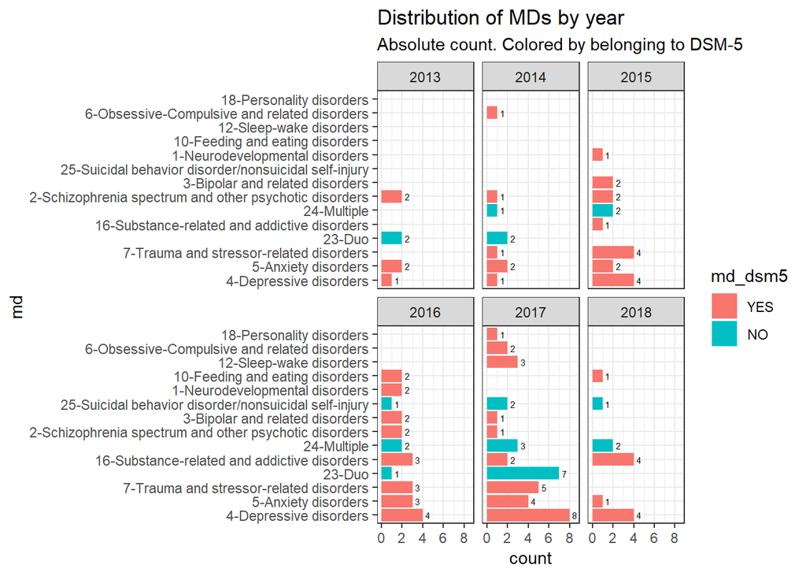

Remarks:

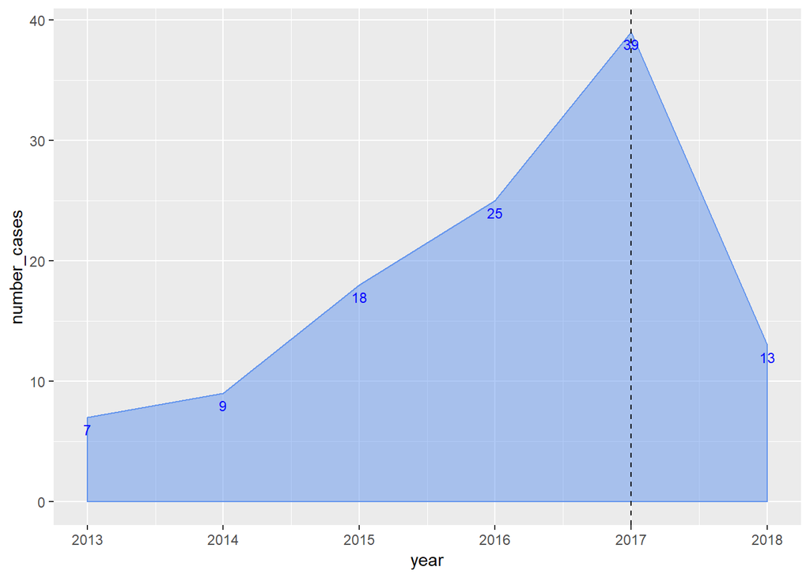

Remarks:

### Comorbidity in cases 23-Dual and 24-multiple?

Reminder: About 23.4% (N=26) are 23-Dual, 24-Multiple or 25-Suicidal Behavior Disorder/Nonsuicidal Self-Injury. We look now at 23-Dual and 24-Multiple MDs, and check the field *md_mul* that lists the mutliple MDs.

A way to visualize the two discrete variables is by using a bar plot (counts) and a stacked bar plot (proportions).

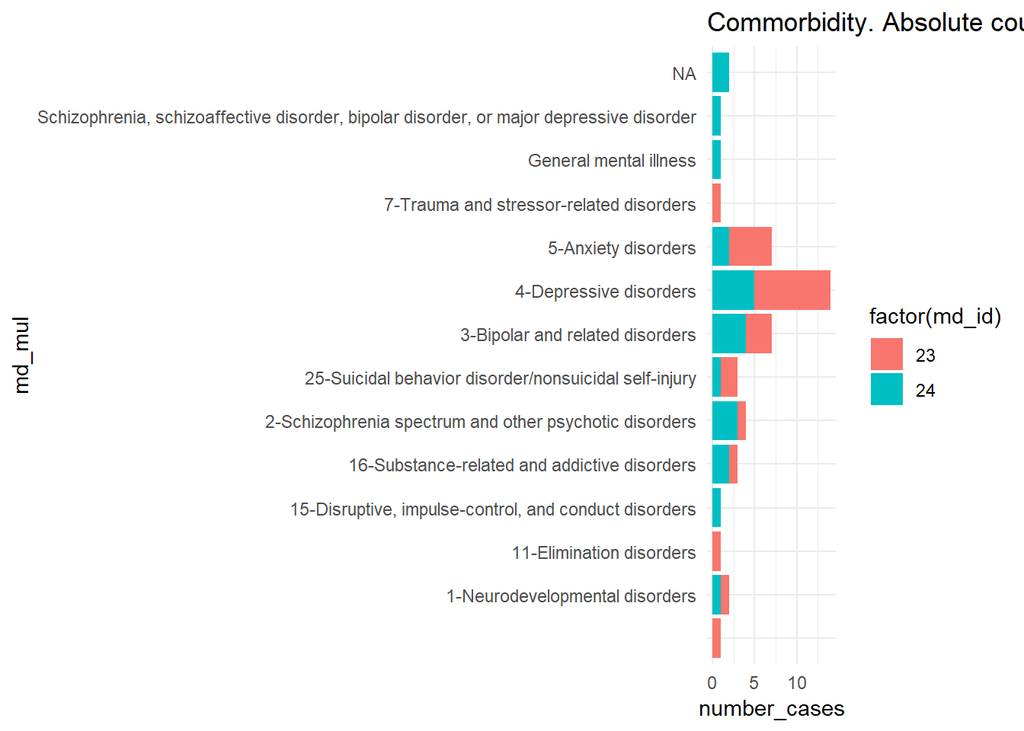

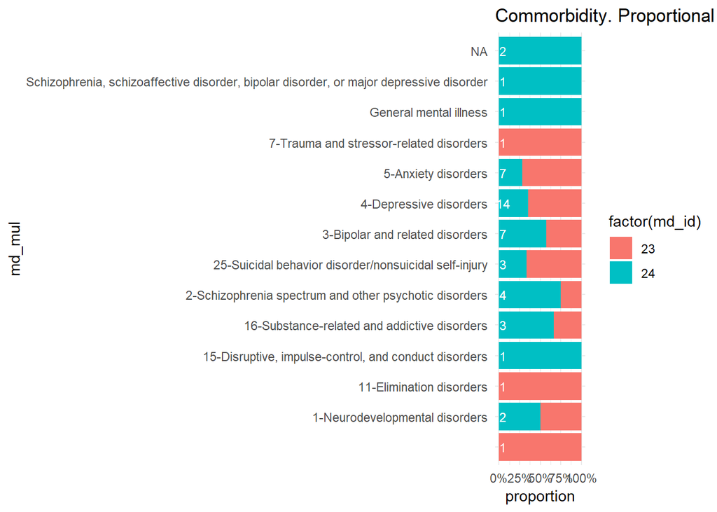

Same as the above stacked bar plot but using a bubble plot.

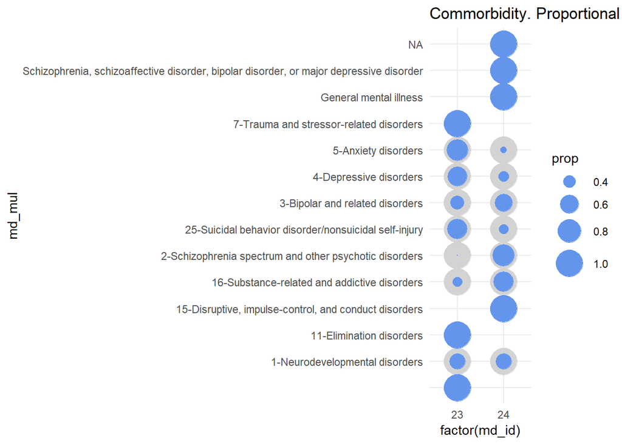

### What subtypes of illnesses are mentioned (in the papers) per each category of mental disorder in DSM-5?

We look at MDs which are categorised according to the DSM-5 (id <= 22 or id = 25), and check the field *md_sub*.

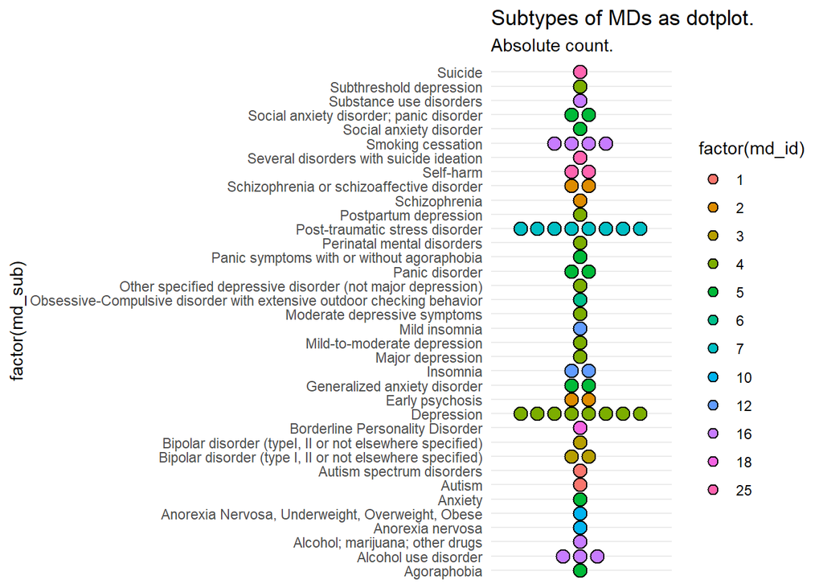

## Exploratory analysis of mental disorders and apps

### Number of apps related to each MD

Let’s start simple: *How many apps are related to the MDs and subtypes?*

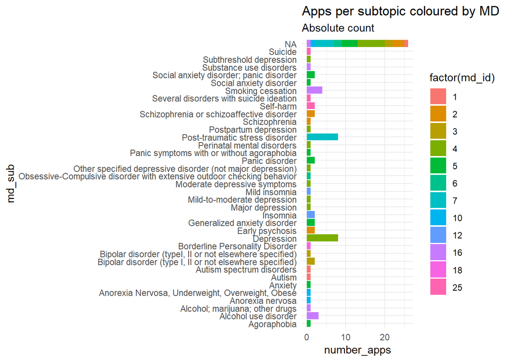

Note that in the above bar chart, there is a significant proportion of app whose subtopic is not defined (NA). Are therefore these apps too much generic?

We use a treemap diagram to represent hierarchical data in the form of nested rectangles, the area of each corresponding to its numerical value. i.e. the count of apps per subtype and main MD

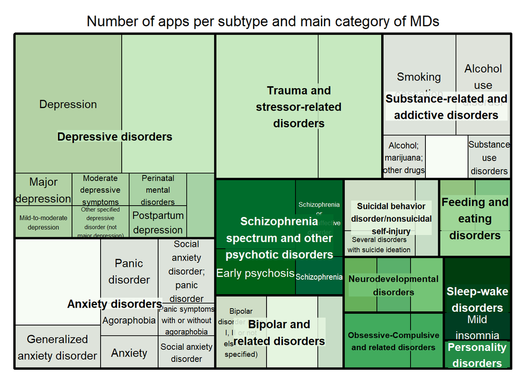

### Sensory capabilities related to each MD

| DSM-5 Mental Disorder | MD Subtype | Accelerometer | Ggyroscope | GPS | Microphone | App Name |
| --- | --- | --- | --- | --- | --- | --- |
| Anxiety disorders | Agoraphobia | NO | NO | NO | NO | Agoraphobia Free ; Stress Free |
| Anxiety disorders | Anxiety | NO | NO | NO | NO | AnxietyCoach |
| Anxiety disorders | Generalized anxiety disorder | NOT KNOWN | NOT KNOWN | NOT KNOWN | NOT KNOWN | NA |
| Anxiety disorders | Generalized anxiety disorder | NO | NO | NO | NO | UNKNOWN |
| Anxiety disorders | Panic disorder | YES | NO | NO | NO | NA |
| Anxiety disorders | Panic disorder | NO | NO | NO | NO | GET.ON PAPP |
| Anxiety disorders | Panic symptoms with or without agoraphobia | NO | NO | NO | NO | GET.ON PAPP |
| Anxiety disorders | Social anxiety disorder | NO | NO | NO | NO | CBT Assistant |
| Anxiety disorders | Social anxiety disorder; panic disorder | NO | NO | NO | NO | Ångesthjälpen |
| Anxiety disorders | Social anxiety disorder; panic disorder | NO | NO | NO | NO | NA |
| Anxiety disorders | NA | NOT KNOWN | NOT KNOWN | NOT KNOWN | NOT KNOWN | Lantern |
| Anxiety disorders | NA | NO | YES | NO | NO | Public Speech Trainer (PST) |
| Anxiety disorders | NA | NO | NO | NO | NO | UNKNOWN |
| Anxiety disorders | NA | NO | NO | NO | NO | PsychAssist |
| Bipolar and related disorders | Bipolar disorder (type I, II or not elsewhere specified) | NO | NO | NO | NO | SIMPLe |
| Bipolar and related disorders | Bipolar disorder (type I, II or not elsewhere specified) | NO | NO | NO | NO | SIMPLe |
| Bipolar and related disorders | Bipolar disorder (typeI, II or not elsewhere specified) | NO | NO | NO | NO | SIMPLe |
| Bipolar and related disorders | NA | NO | NO | NO | NO | MyT |
| Bipolar and related disorders | NA | NO | NO | NO | NO | PRISM |
| Depressive disorders | Depression | NOT KNOWN | NOT KNOWN | NOT KNOWN | NOT KNOWN | NA |
| Depressive disorders | Depression | NO | NO | NO | NO | Thought Challenger |
| Depressive disorders | Depression | NO | NO | NO | NO | MedLink |
| Depressive disorders | Depression | YES | NO | YES | NO | Mobile Sensing and Support (MOSS) |
| Depressive disorders | Depression | NO | NO | NO | NO | Moodivate |
| Depressive disorders | Depression | NO | NO | NO | NO | SuperBetter |
| Depressive disorders | Depression | NO | NO | NO | NO | PRIME-D |
| Depressive disorders | Depression | NO | NO | NO | NO | UNKNOWN |
| Depressive disorders | Major depression | NO | NO | NO | NO | UNKNOWN |
| Depressive disorders | Mild-to-moderate depression | NO | NO | NO | NO | MoodHacker |
| Depressive disorders | Moderate depressive symptoms | NO | NO | NO | NO | Dcombat |

[output cut: 59 more lines]

Now, we filter the records that have any value from the “sens_” fields to true. Heatmeap?

```r
heatmap_data <-
    sens_apps %>%
    filter(sens_acc == "YES" | sens_gyr =="YES" | sens_gps == "YES" | sens_mic == "YES")

heatmap_data %>%
    select(`DSM-5 Mental Disorder` = md_desc,
           `MD Subtype` = md_sub,
           `Accelerometer` = sens_acc,
           `Ggyroscope` = sens_gyr,
           `GPS` = sens_gps,
           `Microphone` = sens_mic,
           `App Name` = app_name) %>%
    kable(format = "html", caption = "Apps", escape = FALSE) %>%
    kable_styling(bootstrap_options = c("striped", "hover", "condensed", "responsive"))
```

| DSM-5 Mental Disorder | MD Subtype | Accelerometer | Ggyroscope | GPS | Microphone | App Name |
| --- | --- | --- | --- | --- | --- | --- |
| Anxiety disorders | Panic disorder | YES | NO | NO | NO | NA |
| Anxiety disorders | NA | NO | YES | NO | NO | Public Speech Trainer (PST) |
| Depressive disorders | Depression | YES | NO | YES | NO | Mobile Sensing and Support (MOSS) |
| Depressive disorders | Perinatal mental disorders | NO | NO | YES | NO | MyGamePlan |
| Depressive disorders | NA | NO | NO | YES | NO | NA |
| Neurodevelopmental disorders | Autism | NO | NO | YES | NO | LifePal |
| Neurodevelopmental disorders | Autism spectrum disorders | NO | NO | NO | YES | iCanLearn |
| Obsessive-Compulsive and related disorders | Obsessive-Compulsive disorder with extensive outdoor checking behavior | NO | NO | YES | YES | Geo-Feedback App |
| Schizophrenia spectrum and other psychotic disorders | Schizophrenia | NO | NO | NO | YES | PRIME |
| Schizophrenia spectrum and other psychotic disorders | NA | NO | NO | NO | YES | SlowMo |
| Substance-related and addictive disorders | Alcohol use disorder | YES | NO | NO | NO | Mind the Moment |
| Trauma and stressor-related disorders | Post-traumatic stress disorder | NO | NO | NO | YES | PE Coach |
| Trauma and stressor-related disorders | Post-traumatic stress disorder | NO | NO | YES | YES | Life Armor AND PE Coach AND Positive Activity Jackpot AND Eventful AND Tactical Breather AND Virtual hope Box AND Daily Yoga AND Simply Yoga |
| Trauma and stressor-related disorders | NA | NO | NO | YES | YES | Life Armor AND PE Coach AND Positive Activity Jackpot AND Eventful AND Tactical Breather AND Virtual hope Box AND Daily Yoga AND Simply Yoga |
| Trauma and stressor-related disorders | NA | NO | NO | NO | YES | PE Coach |
| Trauma and stressor-related disorders | NA | NO | NO | NO | YES | PE Coach |
| Trauma and stressor-related disorders | NA | NO | NO | NO | YES | PE Coach |

### BELOW THIS LINE IS NOT VALID